# Géobase du réseau hydrographique du Québec

# Géobase du réseau hydrographique du Québec

Données Québec / Ministère des Ressources naturelles et des Forêts

Personne à contacter**Aurélien Nicosia**Révision pédagogique et statistique

Une ligne préparée correspond à une unité de téléchargement de l'index GRHQ

Voir les résultats R[Source officielle](https://www.donneesquebec.ca/recherche/dataset/grhq)

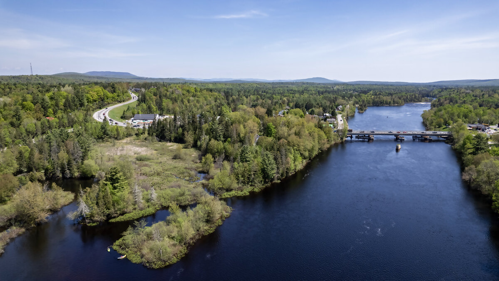

Territoire**Québec**

Niveau**Intermédiaire à avancé**

Structure**Index spatial, métadonnées de téléchargement et référentiel hydrographique**

Format**Index CSV préparé localement; ressources officielles FGDB, SHP, WMS et PDF documentées**

Question de départ

Choisir une unité de téléchargement GRHQ et justifier ce choix.

Potentiel pédagogique**24 / 30**

hydrographieindex de téléchargementdonnées spatialesmétadonnéesunité statistiquesfjointure spatiale

R en action

## Aperçu reproductible

Aperçu léger calculé par R à partir des métadonnées vérifiées afin de garder la fiche rapide et stable au rendu.

Code minimal

```r
library(yaml)

metadata <- yaml::read_yaml("datasets/grhq/metadata.yml")
data.frame(
  champ = c("theme", "territoire", "unite", "niveau"),
  valeur = c(metadata$theme, metadata$geography, metadata$unit, metadata$level)
)
```

Résultats R

Lignes déclarées**16 unités de téléchargement dans l'index CSV préparé**

Colonnes déclarées**11 colonnes dans la table préparée**

Format**Index CSV préparé localement; ressources officielles FGDB, SHP, WMS et PDF documentées**

Aperçu**Métadonnées**

[output not shown]

Lecture statistique

Mini-projets

- Choisir une unité de téléchargement GRHQ et justifier ce choix.
- Comparer les unités complètes et les unités fractionnées de l'index.
- Préparer le plan d'une jointure spatiale avec des stations de qualité de l'eau.

Activités liées

30-45 minutes**Choisir une unité GRHQ avec l'index de téléchargement**

Comment choisir une unité GRHQ avant de télécharger une géodatabase?

2-3 heures**Préparer une analyse spatiale avec la GRHQ**

Comment préparer une analyse spatiale avec la GRHQ sans télécharger inutilement tout le Québec?

## Pourquoi ce jeu est intéressant

La GRHQ est un bon jeu pour enseigner une idée importante en données spatiales : avant de lire une couche géométrique, il faut comprendre l’index, le format, l’unité de téléchargement et la taille implicite des fichiers. La fiche ne transforme donc pas la GRHQ en simple CSV. Elle prépare l’index officiel qui sert à choisir une unité hydrographique, puis elle documente les ressources spatiales détaillées disponibles.

Cette approche est adaptée à un cours de science des données parce qu’elle montre un vrai flux de travail : consulter les métadonnées, choisir un périmètre raisonnable, éviter de télécharger tout le Québec, puis seulement ensuite passer à `sf`, aux cartes et aux jointures spatiales.

## Ce qui a été vérifié

| Élément | Résultat vérifié |
| --- | --- |
| Paquet CKAN | `bfbdeb1d-8398-444b-ad78-ab81f9d14e60` |
| Source officielle | Données Québec / Ministère des Ressources naturelles et des Forêts |
| Ressources dans le paquet | 9 ressources |
| Index CSV préparé ici | 16 unités de téléchargement |
| Régions hydrographiques distinctes dans l’index | 12 |
| Unités complètes | 9 |
| Unités fractionnées en parties | 7 |
| Licence | Attribution (CC-BY 4.0), selon les métadonnées CKAN consultées le 2026-06-21 |
| Dernière modification du paquet CKAN | 2026-06-11 |
| Table préparée | `data/processed/grhq/grhq_index_telechargement.csv` |
| Ressources documentées | `data/processed/grhq/ressources_grhq.csv` |

## Source et conditions

| Champ | Information |
| --- | --- |
| Page Données Québec | https://www.donneesquebec.ca/recherche/dataset/grhq |
| API CKAN | https://www.donneesquebec.ca/recherche/api/3/action/package_show?id=grhq |
| Page MRNF | https://mrnf.gouv.qc.ca/repertoire-geographique/reseau-hydrographique-grhq/ |
| Miroir ouvert.canada.ca | https://open.canada.ca/data/fr/dataset/bfbdeb1d-8398-444b-ad78-ab81f9d14e60 |
| Territoire | Tout le Québec |
| Date d’accès | 2026-06-21 |
| Fréquence de mise à jour | Au besoin selon la page MRNF |
| Redistribution pédagogique | Possible sous réserve du respect de la licence Attribution (CC-BY 4.0) |

## Ce que représente une ligne

Dans la table préparée, une ligne représente une unité de téléchargement de l’index GRHQ. Ce n’est pas une rivière, un lac, un bassin versant, une jonction ou une surface hydrographique.

| Variable | Rôle |
| --- | --- |
| `bloc` | Identifiant de l’unité de téléchargement dans l’index |
| `region_hydrographique` | Région hydrographique extraite du bloc |
| `partie` | Numéro de partie lorsque la région est fractionnée |
| `is_split_unit` | Indique si l’unité est une partie d’une région |
| `unit_kind` | Type d’unité de téléchargement |
| `zone` | Libellé source de la zone |
| `fgdb_url` | URL du fichier FGDB correspondant |

Cette distinction est essentielle. L’index sert à décider quoi télécharger. Les analyses de longueur de cours d’eau, de surfaces hydrographiques ou de connectivité du réseau exigent ensuite de lire une géodatabase détaillée.

## Structure des ressources

| Format | Nombre de ressources CKAN |
| --- | --- |
| PDF | 2 |
| SHP | 2 |
| WMS | 2 |
| CSV | 1 |
| FGDB | 1 |
| HTML | 1 |

| Ressource | Format | Rôle pédagogique |
| --- | --- | --- |
| Index de téléchargement | CSV | Choisir une unité de téléchargement |
| Index de téléchargement | SHP | Visualiser spatialement les unités de téléchargement |
| Répertoire complet | FGDB | Accéder aux géodatabases détaillées |
| Guide de l’utilisateur | PDF | Comprendre la structure du référentiel |
| Carte de téléchargement des UDH | HTML | Sélectionner une unité par interface cartographique |
| Inventaire des UDH disponibles | SHP | Documenter les unités disponibles |
| Service WMS GRHQ simple | WMS | Visualisation légère |
| Service WMS GRHQ détaillée | WMS | Visualisation complète |
| Légendes GRHQ | PDF | Interpréter la symbologie |

## Taille et résultats R vérifiés

| Indicateur | Valeur |
| --- | --- |
| Lignes préparées dans l’index | 16 |
| Colonnes préparées | 11 |
| Régions hydrographiques distinctes | 12 |
| Unités complètes | 9 |
| Unités fractionnées | 7 |
| Ressources CKAN documentées | 9 |

## Unités de téléchargement

| Bloc | Zone | Type |
| --- | --- | --- |
| 00 | Région hydrographique 00 | complète |
| 01 | Région hydrographique 01 | complète |
| 02 | Région hydrographique 02 | complète |
| 03 | Région hydrographique 03 | complète |
| 04 | Région hydrographique 04 | complète |
| 05 | Région hydrographique 05 | complète |
| 06 | Région hydrographique 06 | complète |
| 07_1 | Région hydrographique 07, partie 1 | fractionnée |
| 07_2 | Région hydrographique 07, partie 2 | fractionnée |
| 08 | Région hydrographique 08 | complète |
| 09_1 | Région hydrographique 09, partie 1 | fractionnée |
| 09_2 | Région hydrographique 09, partie 2 | fractionnée |
| 09_3 | Région hydrographique 09, partie 3 | fractionnée |
| 10_1 | Région hydrographique 10, partie 1 | fractionnée |
| 10_2 | Région hydrographique 10, partie 2 | fractionnée |
| 14 | Région hydrographique 14 | complète |

## Lecture statistique

La GRHQ est un référentiel, pas un tableau d’observations indépendantes. Une bonne utilisation pédagogique suit cet ordre :

1. lire l’index;
2. choisir une unité de téléchargement;
3. documenter le format et la projection;
4. lire seulement la couche nécessaire;
5. interpréter les résultats comme des objets géographiques, pas comme un échantillon statistique ordinaire.

La page MRNF indique que le produit vectoriel est offert en FGDB, avec système de projection CCL, à une échelle de 1/20 000 à 1/50 000 et une précision de 4 à 10 m en planimétrie. Ces informations doivent être conservées dans toute analyse cartographique.

## Concepts enseignables

- index de téléchargement
- métadonnées spatiales
- unité de téléchargement
- système de projection
- données vectorielles
- service WMS
- lecture avec `sf`
- jointure spatiale
- limites computationnelles

## Score zéro déchet

| Dimension | Score | Justification |
| --- | --- | --- |
| Contexte québécois | 3 | Référentiel hydrographique officiel pour le Québec |
| Accessibilité pédagogique | 2 | Très riche, mais technique et volumineux |
| Qualité documentaire | 3 | Page MRNF, guide, index, WMS et métadonnées CKAN |
| Potentiel de nettoyage | 3 | Choix de ressources, index, formats et couches à documenter |
| Potentiel de visualisation | 3 | Cartographie hydrographique naturelle |
| Potentiel de statistique descriptive | 2 | Résumés possibles après lecture de couches spatiales |
| Potentiel d’inférence | 1 | Peu adapté à l’inférence sans question environnementale précise |
| Potentiel de modélisation | 2 | Réseau hydrographique utile pour modèles spatiaux après préparation |
| Potentiel éthique | 2 | Discussion sur territoire, ressources en eau et usages publics |
| Réutilisabilité | 3 | Réutilisable avec qualité de l’eau, inondations et environnement |

Total : 24 sur 30.

## Activité courte

En 30 à 45 minutes, lire l’index préparé, choisir une unité GRHQ et justifier ce choix sans télécharger tout le référentiel.

## Activité longue

En 2 à 3 heures, préparer un plan d’analyse spatiale : choisir une unité, documenter le format FGDB, lister les couches attendues et proposer une jointure avec un autre jeu environnemental.

## Code R minimal

À exécuter depuis la racine du projet.

```r
# Load libraries
library(dplyr)
library(readr)

# Prepare official metadata and download index
source("datasets/grhq/preparation.R")

# Import prepared index
index_grhq <- read_csv(
  "data/processed/grhq/grhq_index_telechargement.csv",
  show_col_types = FALSE
)

# Summarize available units
index_grhq |>
  count(unit_kind, sort = TRUE)

# Select one unit before downloading a geodatabase
unite_choisie <- index_grhq |>
  filter(bloc == "08")

unite_choisie |>
  select(bloc, zone, fgdb_url)
```

## Limites et précautions

- L’index préparé ne contient pas les géométries hydrographiques détaillées.
- Télécharger tout le référentiel peut être inutilement lourd pour un laboratoire.
- Une ligne de l’index n’est pas une entité hydrographique.
- Les analyses de longueur, surface, densité ou connectivité exigent la lecture d’une couche spatiale détaillée.
- Les résultats cartographiques doivent documenter la projection, l’échelle et les simplifications éventuelles.

## Extensions

- Lire une FGDB avec `sf::st_read()` après avoir choisi une unité.
- Comparer le WMS simple et le WMS détaillé.
- Joindre des stations de qualité de l’eau à une unité GRHQ.
- Construire une carte des unités de téléchargement à partir du SHP de l’index.
- Discuter la différence entre référentiel spatial et échantillon statistique.

## Références utilisées

- Données Québec. 2026. Géobase du réseau hydrographique du Québec (GRHQ). https://www.donneesquebec.ca/recherche/dataset/grhq
- Ministère des Ressources naturelles et des Forêts. 2026. Réseau hydrographique, GRHQ. https://mrnf.gouv.qc.ca/repertoire-geographique/reseau-hydrographique-grhq/
- Gouvernement du Canada. 2026. Géobase du réseau hydrographique du Québec (GRHQ), miroir ouvert.canada.ca. https://open.canada.ca/data/fr/dataset/bfbdeb1d-8398-444b-ad78-ab81f9d14e60